# Plastic Debris

Stuart Watt

# Introduction and Setup

I’m using the following packages:

```r
library(tidyverse)
library(purrr)
library(magrittr)
library(treemap)
```

```r
library(mapdata)
library(viridis)
library(lubridate)
```

Logged marine debris is available for download [here](http://marinedebris.engr.uga.edu/newmap/). I’m importing data from 2010 till Feb 19th 2020. There doesn’t seem to be data before 2010. The data is reported marine debris.

```r
data <- list.files(path = "data/", full.names = TRUE) %>%
  lapply(FUN = read_csv, col_types = "ififidddddcfcif") %>%
  reduce(rbind)
```

I’m going to replace the column for time as a date data type, renaming it as simply “Time”:

```r
data$Time <- data$Timestamp %>%
  parse_datetime(format = "%Y%m%d%H%M%S")
data$Timestamp <- NULL
```

# Wrangling

A quick look at the data:

```r
data
```

```
## # A tibble: 363,368 x 15
##    ListID ListName ItemID ItemName LogID Latitude Longitude Altitude
##     <int> <fct>     <int> <fct>    <int>    <dbl>     <dbl>    <dbl>
##  1     22 Marine ~    183 Lumber/~   322     28.0     -82.8     -8.8
##  2     22 Marine ~    183 Lumber/~   323     28.0     -82.8     -8.7
##  3     22 Marine ~    187 Cigaret~   324     28.0     -82.8      0.2
##  4     22 Marine ~    181 Bottle ~   325     28.0     -82.8      0.4
##  5     22 Marine ~    181 Bottle ~   326     28.0     -82.8      0.4
##  6     22 Marine ~    181 Bottle ~   327     28.0     -82.8      1.4
##  7     22 Marine ~    174 Aerosol~   328     28.0     -82.8      1.9
##  8     22 Marine ~    207 Straws     329     28.0     -82.8      2.6
##  9     22 Marine ~    185 Disposa~   330     28.0     -82.8      2
## 10     22 Marine ~    202 Plastic~   331     28.0     -82.8      3
## # ... with 363,358 more rows, and 7 more variables: Quantity <dbl>, `Error
## #   Radius` <dbl>, Location <fct>, Description <chr>, `Material ID` <int>,
## #   `Material Description` <fct>, Time <dttm>
```

Let’s first check for missing values:

```r
data %>% select_if(function(x) any(is.na(x))) %>% colnames()
```

```
## [1] "Location"    "Description"
```

So only these columns contain missing values. We will use an explicit missing value for the location factor:

```r
data$Location <- data$Location %>% fct_explicit_na()
```

Lets see the amount of unique values for each column:

```r
data %>% apply(2, function(x) length(unique(x)))
```

```
##               ListID             ListName               ItemID
##                    1                    1                   55
##             ItemName                LogID             Latitude
##                   55               363368               142707
##            Longitude             Altitude             Quantity
##               136490               135214                  496
##         Error Radius             Location          Description
##                18374                 1458                 8494
##          Material ID Material Description                 Time
##                    8                    8               248436
```

Both “ListID” and “ListName” don’t give us any information, so we will remove them both.

```r
data <- data %>% select(-ListID,-ListName)
```

Lets see if there are any “ItemNames” associated with more than one “Material Descriptions”.

```r
data %>% select(`Material Description`, ItemName) %>%
  distinct() %$%
  table(ItemName) %>%
  as_tibble() %>%
  filter(n > 1)
```

```
## # A tibble: 1 x 2
##   ItemName          n
##   <chr>         <int>
## 1 Rubber Gloves     2
```

So rubber gloves are associated with two material descriptions, but otherwise a one to many relationship exists between “Material Description” and “ItemName”.

```r
data %>% select(`Material Description`, ItemName, Quantity) %>%
  filter(ItemName == "Rubber Gloves") %>%
  group_by(`Material Description`) %>%
  summarise(Quantity = sum(Quantity))
```

```
## # A tibble: 2 x 2
##   `Material Description` Quantity
##   <fct>                     <dbl>
## 1 PLASTIC                    2114
## 2 RUBBER                      155
```

It seems that most rubber gloves are classified as plastic rather than rubber. I’m going to search for any extra descriptions given in the observations to try and gain some insight.

```r
data %>% select(`Material Description`, ItemName, Description) %>%
  filter(ItemName == "Rubber Gloves", !is.na(Description))
```

```
## # A tibble: 33 x 3
##    `Material Descriptio~ ItemName     Description
##    <fct>                 <fct>        <chr>
##  1 PLASTIC               Rubber Glov~ Found on wassaw island Oct. 21 with ~
##  2 PLASTIC               Rubber Glov~ undefined
##  3 PLASTIC               Rubber Glov~ undefined
##  4 PLASTIC               Rubber Glov~ thermal
##  5 PLASTIC               Rubber Glov~ Near water
##  6 PLASTIC               Rubber Glov~ Taste of Omaha Cleanup
##  7 PLASTIC               Rubber Glov~ Taste of Omaha Cleanup
##  8 PLASTIC               Rubber Glov~ 2 diff kinds
##  9 PLASTIC               Rubber Glov~ undefined
## 10 PLASTIC               Rubber Glov~ Latex
## # ... with 23 more rows
```

Distribution of observed debris:

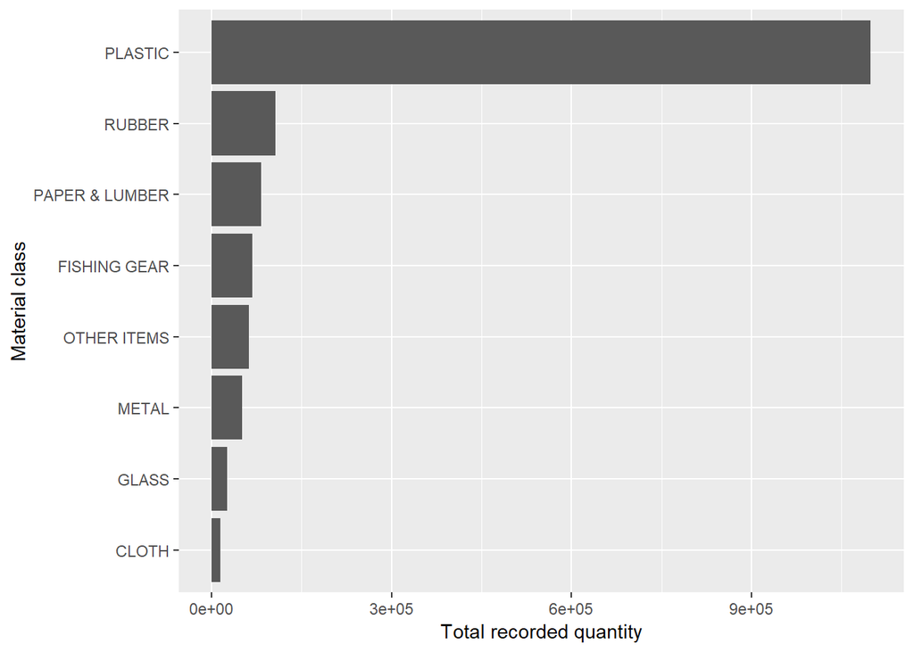

```r
data %>% select(Quantity,Description,`Material Description`) %>%
  group_by(`Material Description`) %>%
  summarise(Quantity = sum(Quantity)) %>%
  ggplot(aes(x = reorder(`Material Description`, Quantity), y = Quantity)) +
    geom_col() +
    ylab("Total recorded quantity") +
    xlab("Material class") +
    coord_flip()
```

So the most populated material class is Plastic. Note that this does not necessarily mean that plastic is the largest quantity of debris, just that the individual number of items categorised is largest.

A tree map of material quantities:

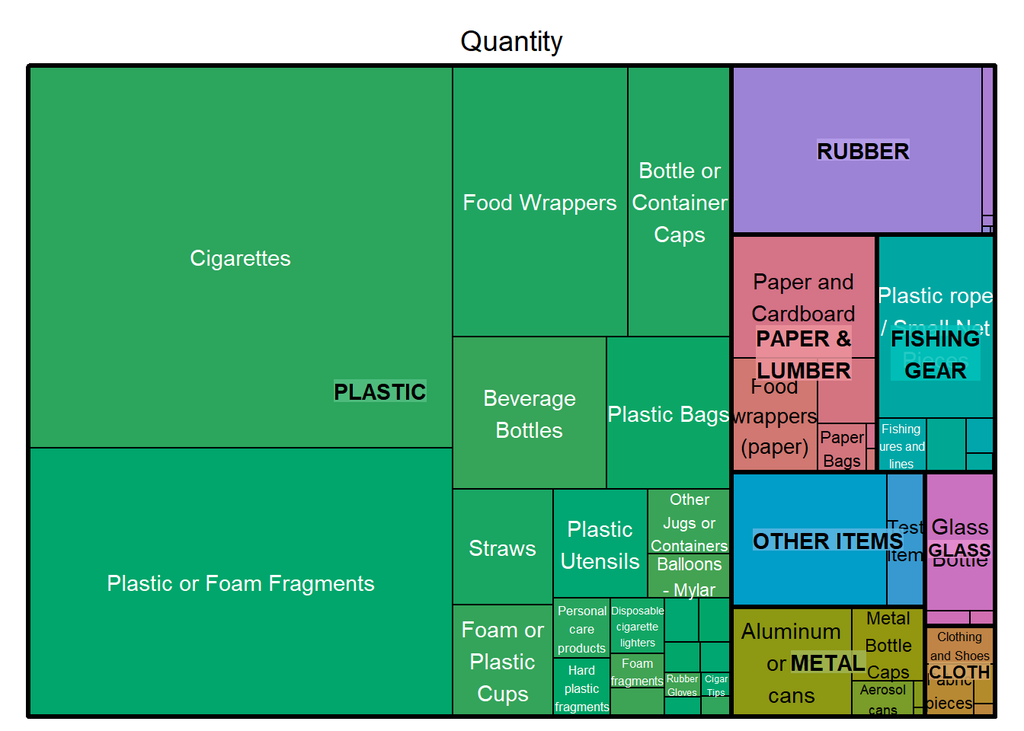

```r
data %>%
  select(`Material Description`, ItemName, Quantity) %>%
  group_by(`Material Description`, ItemName) %>%
  summarise(Quantity = sum(Quantity)) %>%
  treemap(index = c("Material Description", "ItemName"),
          vSize = "Quantity", draw = TRUE)
```

Cigarettes are the most common item recorded. Perhaps some of the debris is not actually from the sea, but rather from people littering by the coastline? Does debris littered on the coastline end up in the oceans?

We have locational data, so lets check for any geographical observation bias.

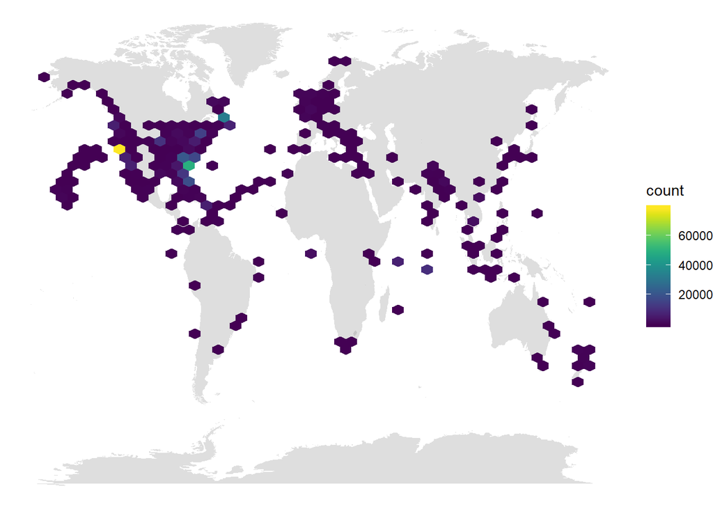

```r
world <- map_data("world")
data %>%
  select(Latitude, Longitude, Quantity, Location, `Material Description`) %>%
  ggplot() +
    geom_polygon(data = map_data("world"), aes(x = long, y = lat, group = group), fill = "grey", alpha = 0.5) +
    geom_hex(aes(x = Longitude, y = Latitude), bins = 50) +
    scale_fill_viridis() +
    theme_void()
```

There seems to be a strong bias towards North America in our dataset. We will try a logarithmic plot to see things more clearly:

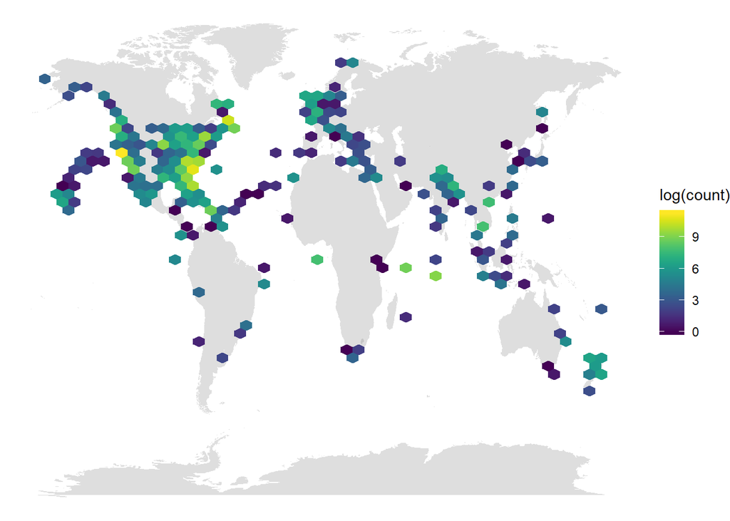

```r
data %>%
  select(Latitude, Longitude, Quantity, Location, `Material Description`) %>%
  ggplot() +
    geom_polygon(data = map_data("world"), aes(x = long, y = lat, group = group), fill = "grey", alpha = 0.5) +
    geom_hex(aes(x = Longitude, y = Latitude, fill = stat(log(count))), bins = 50) +
    scale_fill_viridis() +
    theme_void()
```

We need to know how reliable the location data is. I’m going to filter for “united kingdom” in the location field and plot the raw coordinates.

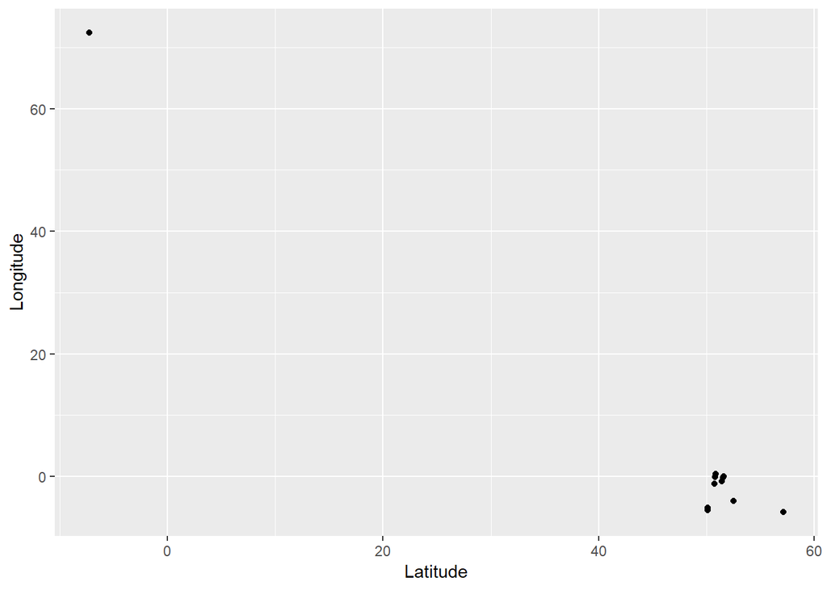

```r
data %>%
  mutate(Location = str_to_lower(Location)) %>%
  filter(str_detect(Location, "united kingdom")) %>%
  select(Latitude, Longitude) %>%
  ggplot(aes(x = Latitude, y = Longitude)) +
    geom_point(position = "jitter")
```

# Questions

## Distribution of plastic by location.

Are the distributions of plastic fairly constant for the locations with the most observations? Let’s look:

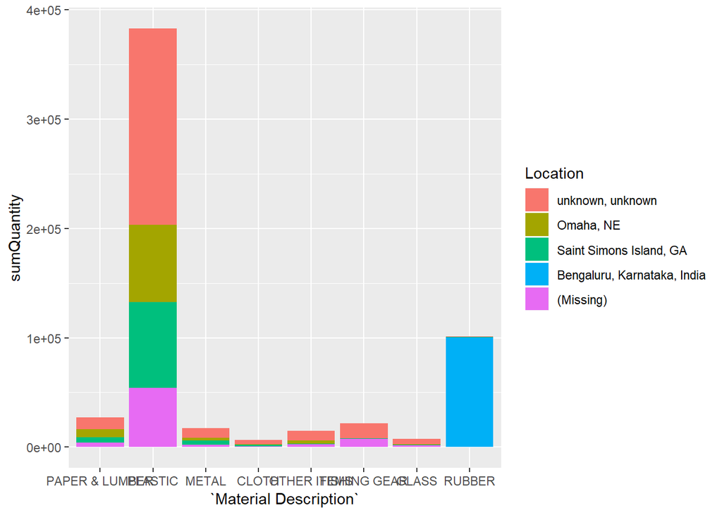

```r
topLocations <- data %>%
  group_by(Location) %>%
  summarise(sumQuantity = sum(Quantity)) %>%
  arrange(desc(sumQuantity)) %>%
  top_n(5,sumQuantity)

data %>%
  filter(Location %in% topLocations$Location) %>%
  group_by(Location, `Material Description`) %>%
  summarise(sumQuantity = sum(Quantity)) %>%
  arrange(desc(sumQuantity)) %>%
  ggplot(aes(x = `Material Description`, y = sumQuantity, fill = Location)) +
    geom_col()
```

We see that the Location “unknown” has the most plastic… note that this is distinct from “(Missing)”, which was our original NA values. Maybe we should merge these.

## Question: Are observed plastic item proportions time invariant?

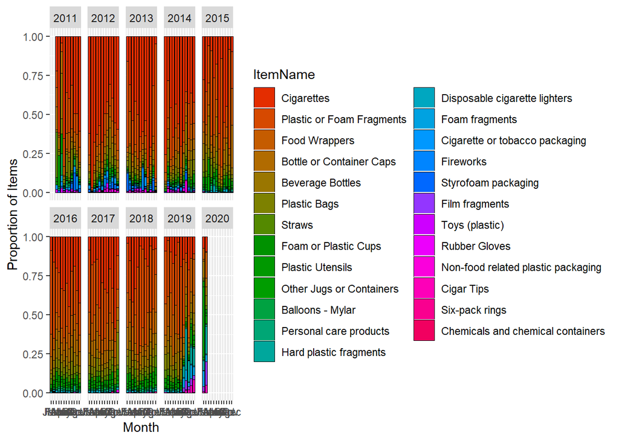

```r
plastic_ordered <- data %>%
  filter(`Material Description` == "PLASTIC") %>%
  select(ItemName, Quantity) %>%
  group_by(ItemName) %>%
  summarise(Total = sum(Quantity)) %>%
  arrange(desc(Total))

data$ItemName <- factor(data$ItemName, plastic_ordered$ItemName)

data %>%
  filter(`Material Description` == "PLASTIC") %>%
  mutate(month = month(Time, label = TRUE),
         year = as.integer(year(Time))) %>%
  filter(year > 2010) %>%
  group_by(month, year, ItemName) %>%
  summarise(`Total Quantity` = sum(Quantity)) %>%
  ggplot(aes(x = month, y = `Total Quantity`, fill = ItemName)) +
    geom_col(colour = "black", size = 0.2, position = "fill") +
    facet_wrap(~year, nrow = 2) +
    scale_fill_hue(l=50, c=150) +
    xlab("Month") +
    ylab("Proportion of Items")
```

```r
    #scale_fill_viridis_d(option = "magma")

#ggsave("pastic_debris_plot.png", width = 60, height = 30, units = "cm")
```

# 4th July and Firework link? (Karen’s Idea)

```r
data %>%
  filter(`Material Description` == "PLASTIC") %$%
  unique(ItemName) %>%
  print()
```

```
##  [1] Cigarettes                         Bottle or Container Caps
##  [3] Straws                             Disposable cigarette lighters
##  [5] Plastic or Foam Fragments          Cigarette or tobacco packaging
##  [7] Food Wrappers                      Toys (plastic)
##  [9] Beverage Bottles                   Foam or Plastic Cups
## [11] Plastic Utensils                   Plastic Bags
## [13] Styrofoam packaging                Balloons - Mylar
## [15] Personal care products             Other Jugs or Containers
## [17] Six-pack rings                     Fireworks
## [19] Chemicals and chemical containers  Rubber Gloves
## [21] Non-food related plastic packaging Cigar Tips
## [23] Hard plastic fragments             Foam fragments
## [25] Film fragments
## 25 Levels: Cigarettes Plastic or Foam Fragments ... Chemicals and chemical containers
```